# Przedstawienie rankingu brytyjskich uniwersytetów - Projekt

Michał Koziński

02-02-2022

## Przedstawienie danych

### Główny ranking

Pierwszym przedstawionym zbiorem danych pochodzących z rankingu *“The Complete University Guide”* z 2022 roku, jest zbiór 130 Uniwerystetów z Wielkiej Brytanii, w którym zostały one zestawione ze sobą w kilku różnych kategoriach. Dane pochodzące ze strony są wynikami procentowymi uzyskanych punktów w poszczególnych kategoriach.

Wyświetlię tylko 15 pierwszych linijek i dodam poniżej przewijaną wersję dla zachowania przejrzystości dokumentu.

#### Zbiór przedstawiony jest w domyślnym sortowaniu według *całkowitego wyniku*.

| Nazwa Universytetu | Całkowity wynik | Próg przyjęcia | Satysfakcja studentów | Jakość badań | Perspektywy absolwentów |
| --- | --- | --- | --- | --- | --- |
| University of Oxford | 100% | 96% | - | 83% | 90% |
| University of Cambridge | 99% | 99% | - | 83% | 90% |
| London School of Economics and Poli... | 96% | 85% | 80% | 84% | 91% |
| University of St Andrews | 95% | 100% | 86% | 78% | 80% |
| Imperial College London | 90% | 93% | 80% | 84% | 95% |
| Durham University | 89% | 88% | 80% | 78% | 85% |
| Loughborough University | 87% | 72% | 84% | 74% | 83% |
| UCL (University College London) | 85% | 89% | 79% | 80% | 85% |
| University of Warwick | 84% | 78% | 81% | 81% | 84% |
| University of Bath | 84% | 81% | 81% | 79% | 88% |
| Lancaster University | 82% | 69% | 81% | 79% | 78% |
| University of Edinburgh | 80% | 90% | 77% | 79% | 80% |
| University of Manchester | 79% | 79% | 79% | 79% | 81% |
| University of Exeter | 79% | 76% | 81% | 77% | 80% |
| University of Southampton | 78% | 73% | 81% | 79% | 80% |

Data source: https://www.thecompleteuniversityguide.co.uk/league-tables/rankings

| University | OverallScore | EntryStandards | StudentSatisfaction | ResearchQuality | GraduateProspects |
| --- | --- | --- | --- | --- | --- |
| University of Oxford | 100 | 96 | NA | 83 | 90 |
| University of Cambridge | 99 | 99 | NA | 83 | 90 |
| London School of Economics and Poli… | 96 | 85 | 80 | 84 | 91 |
| University of St Andrews | 95 | 100 | 86 | 78 | 80 |
| Imperial College London | 90 | 93 | 80 | 84 | 95 |
| Durham University | 89 | 88 | 80 | 78 | 85 |
| Loughborough University | 87 | 72 | 84 | 74 | 83 |
| UCL (University College London) | 85 | 89 | 79 | 80 | 85 |
| University of Warwick | 84 | 78 | 81 | 81 | 84 |
| University of Bath | 84 | 81 | 81 | 79 | 88 |
| Lancaster University | 82 | 69 | 81 | 79 | 78 |
| University of Edinburgh | 80 | 90 | 77 | 79 | 80 |
| University of Manchester | 79 | 79 | 79 | 79 | 81 |
| University of Exeter | 79 | 76 | 81 | 77 | 80 |
| University of Southampton | 78 | 73 | 81 | 79 | 80 |
| University of Glasgow | 77 | 95 | 81 | 77 | 78 |
| University of Bristol | 77 | 79 | 79 | 79 | 82 |
| University of York | 76 | 72 | 81 | 79 | 80 |
| University of Birmingham | 75 | 73 | 78 | 77 | 83 |
| University of Leeds | 75 | 76 | 79 | 78 | 80 |
| King’s College London, University o… | 75 | 80 | 77 | 81 | 85 |
| University of East Anglia UEA | 74 | 64 | 81 | 78 | 77 |
| Heriot-Watt University | 73 | 82 | 80 | 76 | 78 |
| University of Nottingham | 73 | 70 | 79 | 77 | 84 |
| Cardiff University | 73 | 69 | 79 | 82 | 83 |
| University of Sheffield | 72 | 72 | 81 | 79 | 79 |
| University of Essex | 72 | 56 | 81 | 76 | 71 |
| University of Dundee | 72 | 86 | 82 | 76 | 81 |
| Swansea University | 72 | 63 | 82 | 77 | 80 |
| University of Strathclyde | 72 | 95 | 80 | 76 | 81 |

[output cut: 100 more lines]

Data source:

https://www.thecompleteuniversityguide.co.uk/league-tables/rankings

### Zestawienie w różnych kategoriach.

Przedstawię teraz ranking w kilku przykładowych sortowaniach.

#### Sortowanie według poziomu *satysfakcji studentów*.

| Nazwa Universytetu | Całkowity wynik | Próg przyjęcia | Satysfakcja studentów | Jakość badań | Perspektywy absolwentów |
| --- | --- | --- | --- | --- | --- |
| University of St Andrews | 95% | 100% | 86% | 78% | 80% |
| Aberystwyth University | 61% | 57% | 86% | 71% | 63% |
| Abertay University | 46% | 67% | 85% | 54% | 62% |
| Loughborough University | 87% | 72% | 84% | 74% | 83% |
| Arts University Bournemouth | 61% | 69% | 84% | 58% | 57% |
| Robert Gordon University | 59% | 72% | 84% | 59% | 76% |

Data source: https://www.thecompleteuniversityguide.co.uk/league-tables/rankings

#### Sortowanie według poziomu *perspektyw absolwentów*.

| Nazwa Universytetu | Całkowity wynik | Próg przyjęcia | Satysfakcja studentów | Jakość badań | Perspektywy absolwentów |
| --- | --- | --- | --- | --- | --- |
| Imperial College London | 90% | 93% | 80% | 84% | 95% |
| London School of Economics and Poli... | 96% | 85% | 80% | 84% | 91% |
| University of Oxford | 100% | 96% | - | 83% | 90% |
| University of Cambridge | 99% | 99% | - | 83% | 90% |
| St George's, University of London | 60% | 70% | 77% | 75% | 89% |
| University of Bath | 84% | 81% | 81% | 79% | 88% |

Data source: https://www.thecompleteuniversityguide.co.uk/league-tables/rankings

### Rankingi dla poszczególnych przedmiotów

[output not shown]

##### Z tego samego źródła jesteśmy w stanie pozyskać rankingi danych uniwersytetów na poszczególnych kierunkach.

##### Do przedstawienia w projekcie wziąłem rankig dla kierunku *Computer Science*.

$$\\[1in]$$

[output not shown]

##### Dodatkowo do wglądu uniwersytety posortowane względem satysfakcji studentów.

##### Ponadto widać ich pozycje w rankingu ogólnym dla tego kierunku.

$$\\[1in]$$

[output not shown]

##### Tym razem ranking dla kierunku *Matematyka* posortowany względem *Progu przyjęcia*.

##### Tutaj również widać pozycje uniwersytetów w rankingu ogólnym dla tego kierunku.

$$\\[1in]$$

$$\\[1in]$$

## Druga część zbioru

Wróćmy teraz do rankingu ogólnego i poszerzmy go na podstawie rzeczy także dostępnych na stronie. Oferuje ona możliwość pobrania rankingów z poprzednich lat w formacie *csv*, z czego skorzystam do rozbudowania naszego zbioru danych.

### Wykresy pozycji

Teraz nasze dane możemy wykorzystać przykładowo do przedstawienia jakie pozycje na przestrzeni lat zajmowały konkretne uczelnie. Jako pierwszą próbkę wezmę uczelnie, które w ostatnim roku zajęły 5 najwyższych lokat w rankingu ogólnym.

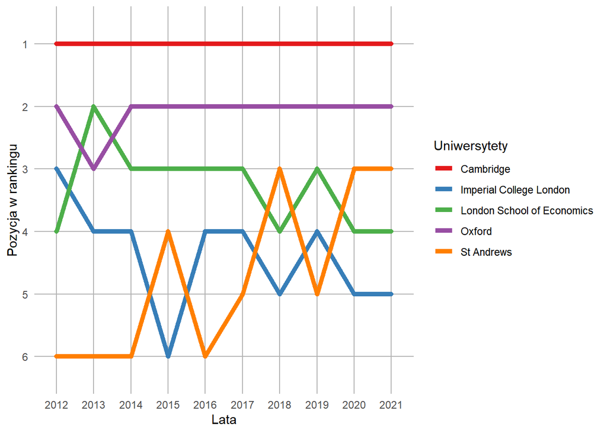

Jak widać wykres nie jest zbyt spektakularany, a wynika to z tego, że uczelnie które wziąłem do jego wygenerowania, od lat zajmują wysokie miejsca w rankingu.

Sprawdźmy zatem uczelnie z dalszych pozycji, by zobaczyć czy w ich sytuacji wykres będzie wyglądał podobnie. Naszym zbiorem będą teraz uczelnie, które w 2021 roku zajęły odpowienio miejsca 50,51,52,53 i 54.

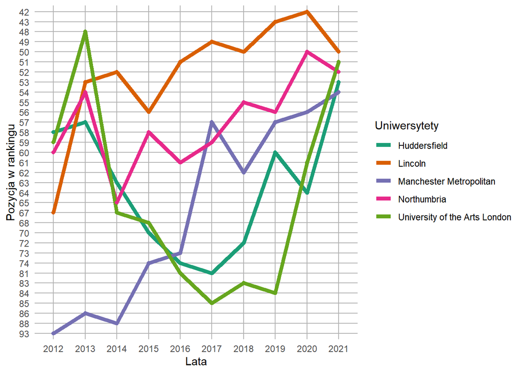

Jak widać, tym razem wykres wygląda o wiele ciekawiej, po czym możemy wnioskować, że w środku stawki walka co roku jest zaciekła.

#### Wykres satysfakcji studentów

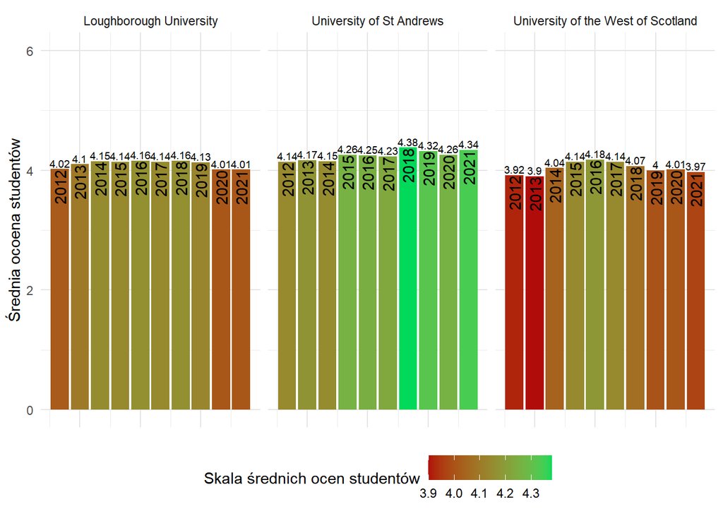

Jak widać zajmowane pozycje w rankingu pokrywają się ze średnią satysfakcją studentów.

$$\\[1in]$$

### Źródła

##### Strona z rankingiem z obecnego roku i z rankingami z poprzednich lat (do pobrania):

https://www.thecompleteuniversityguide.co.uk/league-tables/rankings

##### Strony z rankingami dla poszczególnych przedmiotów:

*Computer Science*:

https://www.thecompleteuniversityguide.co.uk/league-tables/rankings/computer-science

*Mathematics*:

https://www.thecompleteuniversityguide.co.uk/league-tables/rankings/mathematics